# Charan PGM4

```python
1. (Feature Extraction)
* Resize each cropped image to a 224 × 224 pixel image.
```

```python
import os
from PIL import Image
from torchvision import transforms

# Path to the cropped images folder
base_folder = r"C:\Users\thota\Documents\Datamining\Programming4\Cropped"

# Output folder for resized images
output_folder = r"C:\Users\thota\Documents\Datamining\Programming4\Resized"
os.makedirs(output_folder, exist_ok=True)

# Define a transformation pipeline
resize_transform = transforms.Compose([
    transforms.Resize((224, 224)),  # Resize to 224x224
])

# Traverse subdirectories and resize images
for class_folder in os.listdir(base_folder):
    class_path = os.path.join(base_folder, class_folder)
    if os.path.isdir(class_path):  # Check if it's a directory
        # Create corresponding subfolder in the output directory
        output_class_folder = os.path.join(output_folder, class_folder)
        os.makedirs(output_class_folder, exist_ok=True)

        for image_name in os.listdir(class_path):
            if image_name.endswith((".jpg", ".png", ".jpeg")):  # Ensure it's an image
                img_path = os.path.join(class_path, image_name)
                img = Image.open(img_path)
                resized_img = resize_transform(img)

                # Save the resized image
                resized_img.save(os.path.join(output_class_folder, image_name))

print("Image resizing complete. Resized images saved to:", output_folder)
```

```
Image resizing complete. Resized images saved to: C:\Users\thota\Documents\Datamining\Programming4\Resized
```

```python
* Normalize the resized image dataset.
```

```python
import torch
from torchvision import transforms
from PIL import Image
import os

# Path to the resized images folder
resized_folder = r"C:\Users\thota\Documents\Datamining\Programming4\Resized"

# Output folder for normalized images
normalized_folder = r"C:\Users\thota\Documents\Datamining\Programming4\Normalized"
os.makedirs(normalized_folder, exist_ok=True)

# Define normalization pipeline
normalize_transform = transforms.Compose([
    transforms.ToTensor(),  # Convert image to tensor
    transforms.Normalize(mean=[0.485, 0.456, 0.406], std=[0.229, 0.224, 0.225])  # Normalize
])

# Traverse subdirectories and normalize images
for class_folder in os.listdir(resized_folder):
    class_path = os.path.join(resized_folder, class_folder)
    if os.path.isdir(class_path):
        # Create corresponding subfolder in the normalized directory
        output_class_folder = os.path.join(normalized_folder, class_folder)
        os.makedirs(output_class_folder, exist_ok=True)

        for image_name in os.listdir(class_path):
            if image_name.endswith((".jpg", ".png", ".jpeg")):
                img_path = os.path.join(class_path, image_name)
                img = Image.open(img_path)
                img_tensor = normalize_transform(img)

                # Save normalized tensor as a .pt file
                torch.save(img_tensor, os.path.join(output_class_folder, image_name + ".pt"))

print("Normalization complete. Normalized tensors saved to:", normalized_folder)
```

```
Normalization complete. Normalized tensors saved to: C:\Users\thota\Documents\Datamining\Programming4\Normalized
```

- Extract features for each image from the last convolution layer of “ResNet18”

```python
import torch
import torchvision.models as models
from torchvision import transforms
from torch.utils.data import DataLoader, Dataset
import os
import warnings

# Suppress FutureWarnings related to torch.load
warnings.filterwarnings("ignore", category=FutureWarning)

# Path to normalized images
normalized_folder = r"C:\Users\thota\Documents\Datamining\Programming4\Normalized"

# Output folder for extracted features
features_folder = r"C:\Users\thota\Documents\Datamining\Programming4\Extracted_Features"
os.makedirs(features_folder, exist_ok=True)

# Custom Dataset for loading images
class ImageDataset(Dataset):
    def __init__(self, folder_path):
        self.image_paths = []
        self.labels = []
        self.classes = sorted(os.listdir(folder_path))
        for class_idx, class_name in enumerate(self.classes):
            class_path = os.path.join(folder_path, class_name)
            for image_name in os.listdir(class_path):
                if image_name.endswith(".pt"):  # Load PyTorch tensors
                    self.image_paths.append(os.path.join(class_path, image_name))
                    self.labels.append(class_idx)

    def __len__(self):
        return len(self.image_paths)

    def __getitem__(self, idx):
        img_tensor = torch.load(self.image_paths[idx], weights_only=True)  # Load tensor with safety
        label = self.labels[idx]
        return img_tensor, label

# Load normalized dataset
dataset = ImageDataset(normalized_folder)
dataloader = DataLoader(dataset, batch_size=32, shuffle=False)

# Load pre-trained ResNet18
resnet18 = models.resnet18(weights=models.ResNet18_Weights.DEFAULT)
resnet18.eval()  # Set model to evaluation mode

# Register forward hook to extract features from the last convolutional layer
features = []

def hook(module, input, output):
    features.append(output)

# Attach hook to the last convolutional layer
layer = resnet18.layer4[-1]
hook_handle = layer.register_forward_hook(hook)

# Process the dataset to extract features
for idx, (inputs, _) in enumerate(dataloader):
    with torch.no_grad():
        # Use CPU for processing if GPU is unavailable
        inputs = inputs.to(torch.device('cpu'))  # Move to CPU
        resnet18(inputs)  # Forward pass to activate hook

    # Print progress for each batch
    print(f"Processed batch {idx+1}/{len(dataloader)}")

    # Save the extracted features (output of the hook)
    for i in range(len(features)):
        feature_path = os.path.join(features_folder, f"features_batch_{idx+1}.pt")
        torch.save(features[i], feature_path)

# Remove hook after feature extraction
hook_handle.remove()

# Print confirmation message
print(f"Feature extraction complete. Features saved to: {features_folder}")

# List the saved feature files in the folder
saved_files = os.listdir(features_folder)
print("Saved feature files:")
for file in saved_files:
    print(file)
```

```
Processed batch 1/21
Processed batch 2/21
Processed batch 3/21
Processed batch 4/21
Processed batch 5/21
Processed batch 6/21
Processed batch 7/21
Processed batch 8/21
Processed batch 9/21
Processed batch 10/21
Processed batch 11/21
Processed batch 12/21
Processed batch 13/21
Processed batch 14/21
Processed batch 15/21
Processed batch 16/21
Processed batch 17/21
Processed batch 18/21
Processed batch 19/21
Processed batch 20/21
Processed batch 21/21
Feature extraction complete. Features saved to: C:\Users\thota\Documents\Datamining\Programming4\Extracted_Features
Saved feature files:
features_batch_1.pt
features_batch_10.pt
features_batch_11.pt
features_batch_12.pt
features_batch_13.pt
features_batch_14.pt
features_batch_15.pt
features_batch_16.pt
features_batch_17.pt
features_batch_18.pt
features_batch_19.pt
features_batch_2.pt
features_batch_20.pt
features_batch_21.pt
features_batch_3.pt
features_batch_4.pt
features_batch_5.pt
features_batch_6.pt
features_batch_7.pt
features_batch_8.pt
features_batch_9.pt
```

We employed the TorchVision library's ResNet18 model for feature extraction. Features from ResNet18's last convolutional layer were extracted using the model. The following source provided instructions for utilizing a forward hook in PyTorch to retrieve features from a pre-trained model:

- Kozodoi, A. (2021). *Extracting Features from a Pretrained Neural Network: ResNet18 in PyTorch*. Retrieved from https://kozodoi.me/blog/20210527/extracting-features.
2. (Dimension Reduction) Perform dimension reduction on your new dog image representation dataset

to reduce the dimension to 2

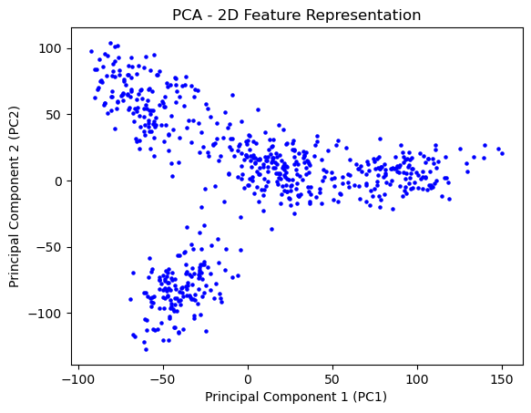

```
Original feature shape: (653, 25088)
Reduced feature shape: (653, 2)
Explained variance ratio: [0.07612507 0.06281152]
```

```python
import torch
import os
import numpy as np
from sklearn.decomposition import PCA
import matplotlib.pyplot as plt

# Path to the folder containing the extracted features
features_folder = r"C:\Users\thota\Documents\Datamining\Programming4\Extracted_Features"

# Load all the extracted features
features = []
feature_files = os.listdir(features_folder)

# Load features from each batch file
for feature_file in feature_files:
    if feature_file.endswith(".pt"):
        feature_path = os.path.join(features_folder, feature_file)
        feature_tensor = torch.load(feature_path)

        # Check the shape of the feature tensor and flatten it if necessary
        feature_tensor = feature_tensor.view(feature_tensor.size(0), -1)  # Flatten each feature tensor

        features.append(feature_tensor.cpu().numpy())  # Convert to numpy array

# Stack all the features into a single numpy array
features = np.vstack(features)

# Perform PCA to reduce to 2D
pca = PCA(n_components=2)
features_2d = pca.fit_transform(features)

# Plot the 2D features
plt.scatter(features_2d[:, 0], features_2d[:, 1], c='blue', s=5)
plt.title('PCA - 2D Feature Representation')
plt.xlabel('Principal Component 1 (PC1)')
plt.ylabel('Principal Component 2 (PC2)')
plt.show()

# Optionally, save the reduced features to a CSV file for later use
np.savetxt("reduced_features_pca.csv", features_2d, delimiter=",")
# Print out some information about the reduction process
print(f"Original feature shape: {features.shape}")
print(f"Reduced feature shape: {features_2d.shape}")
print(f"Explained variance ratio: {pca.explained_variance_ratio_}")
```

3. (Clustering Algorithm) Perform clustering using the following approaches on the 2D dataset you preprocessed in Item 2: 1.K-means Clustering (with K=4 We'll use both init='random' and init='k-means++' for K-means clustering.

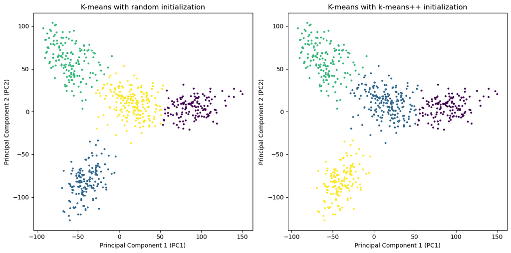

```python
from sklearn.cluster import KMeans
import warnings

# Suppress warnings
warnings.filterwarnings("ignore")
# K-means clustering with init='random'
kmeans_random = KMeans(n_clusters=4, init='random', random_state=42)
labels_random = kmeans_random.fit_predict(features_2d)

# K-means clustering with init='k-means++'
kmeans_kmeans_plus = KMeans(n_clusters=4, init='k-means++', random_state=42)
labels_kmeans_plus = kmeans_kmeans_plus.fit_predict(features_2d)

# Visualize the clustering results for both initializations
plt.figure(figsize=(12, 6))

# K-means with random initialization
plt.subplot(1, 2, 1)
plt.scatter(features_2d[:, 0], features_2d[:, 1], c=labels_random, cmap='viridis', s=5)
plt.title('K-means with random initialization')
plt.xlabel('Principal Component 1 (PC1)')
plt.ylabel('Principal Component 2 (PC2)')

# K-means with k-means++ initialization
plt.subplot(1, 2, 2)
plt.scatter(features_2d[:, 0], features_2d[:, 1], c=labels_kmeans_plus, cmap='viridis', s=5)
plt.title('K-means with k-means++ initialization')
plt.xlabel('Principal Component 1 (PC1)')
plt.ylabel('Principal Component 2 (PC2)')

plt.tight_layout()
plt.show()
```

2. Bisecting K-means

For Bisecting K-means, we'll use BisectingKMeans from sklearn.cluster.

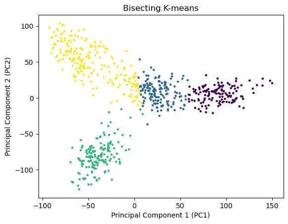

```python
from sklearn.cluster import BisectingKMeans
import warnings

# Suppress warnings
warnings.filterwarnings("ignore")
# Bisecting K-means with init='random'
bisecting_kmeans = BisectingKMeans(n_clusters=4, init='random', random_state=42)
labels_bisecting_kmeans = bisecting_kmeans.fit_predict(features_2d)

# Visualize the results
plt.scatter(features_2d[:, 0], features_2d[:, 1], c=labels_bisecting_kmeans, cmap='viridis', s=5)
plt.title('Bisecting K-means')
plt.xlabel('Principal Component 1 (PC1)')
plt.ylabel('Principal Component 2 (PC2)')
plt.show()
```

3. Spectral Clustering

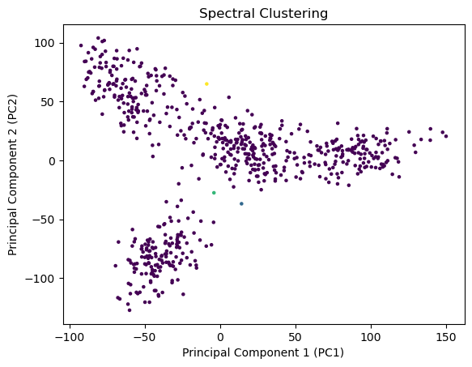

```python
from sklearn.cluster import SpectralClustering
import warnings

# Suppress warnings
warnings.filterwarnings("ignore")
# Spectral clustering
spectral = SpectralClustering(n_clusters=4, random_state=42)
labels_spectral = spectral.fit_predict(features_2d)

# Visualize the results
plt.scatter(features_2d[:, 0], features_2d[:, 1], c=labels_spectral, cmap='viridis', s=5)
plt.title('Spectral Clustering')
plt.xlabel('Principal Component 1 (PC1)')
plt.ylabel('Principal Component 2 (PC2)')
plt.show()
```

4. DBSCAN

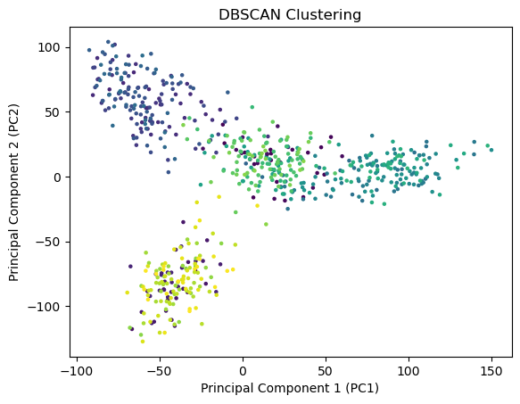

```
DBSCAN eps: 0.2, min_samples: 1
```

```python
from sklearn.cluster import DBSCAN

# Try different values for eps and min_samples
dbscan = DBSCAN(eps=0.2, min_samples=1)  # You can tune these values
labels_dbscan = dbscan.fit_predict(features_2d)

# Visualize the results
plt.scatter(features_2d[:, 0], features_2d[:, 1], c=labels_dbscan, cmap='viridis', s=5)
plt.title('DBSCAN Clustering')
plt.xlabel('Principal Component 1 (PC1)')
plt.ylabel('Principal Component 2 (PC2)')
plt.show()

# Output the eps and min_samples
print(f"DBSCAN eps: 0.2, min_samples: 1")
```

• Agglomerativeclustering(i.e.,hierarchicalclustering)-usesklearn.cluster.AgglomerativeClustering with number of clusters set to 4 (a) Single link (MIN), (0.5 point) (b) Complete link (MAX), (0.5 point) (c) Group Average, and (0.5 point) (d) Ward’s method (0.5 point) Use the four linkage values ‘ward’, ‘complete’, ‘average’, ‘single’ for sklearn.cluster. AgglomerativeClustering

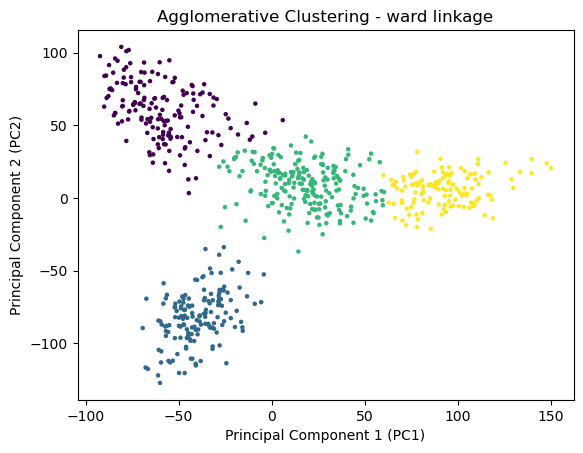

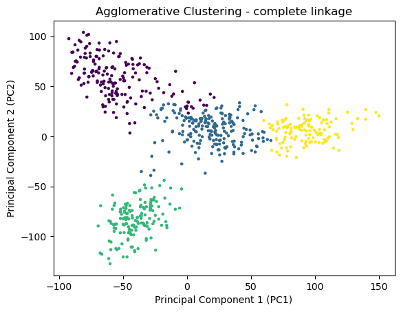

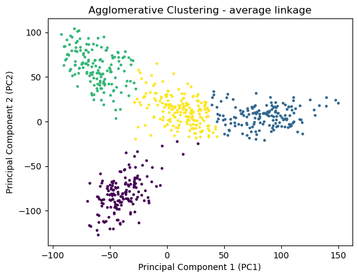

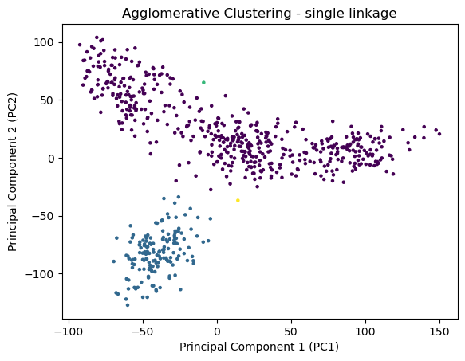

```python
from sklearn.cluster import AgglomerativeClustering

# Agglomerative Clustering with different linkage methods
linkage_methods = ['ward', 'complete', 'average', 'single']
for linkage in linkage_methods:
    agglomerative = AgglomerativeClustering(n_clusters=4, linkage=linkage)
    labels_agglomerative = agglomerative.fit_predict(features_2d)

    # Visualize the results for each linkage method
    plt.scatter(features_2d[:, 0], features_2d[:, 1], c=labels_agglomerative, cmap='viridis', s=5)
    plt.title(f'Agglomerative Clustering - {linkage} linkage')
    plt.xlabel('Principal Component 1 (PC1)')
    plt.ylabel('Principal Component 2 (PC2)')
    plt.show()
```

4. (Clustering Evaluations) For all the methods in Item 3:

```python
import numpy as np
from sklearn.metrics import fowlkes_mallows_score, silhouette_score
from sklearn.cluster import AgglomerativeClustering

# Ensure true_labels matches the exact length of features_2d
true_labels = np.array([0, 1, 2, 3] * (len(features_2d) // 4 + 1))[:len(features_2d)]

# Perform Agglomerative Clustering with different linkage methods
labels_agglomerative_ward = AgglomerativeClustering(n_clusters=4, linkage='ward').fit_predict(features_2d)
labels_agglomerative_complete = AgglomerativeClustering(n_clusters=4, linkage='complete').fit_predict(features_2d)
labels_agglomerative_average = AgglomerativeClustering(n_clusters=4, linkage='average').fit_predict(features_2d)
labels_agglomerative_single = AgglomerativeClustering(n_clusters=4, linkage='single').fit_predict(features_2d)

# Clustering algorithms and their labels
clustering_methods = {
    "K-means (Random)": labels_random[:len(features_2d)],
    "K-means (k-means++)": labels_kmeans_plus[:len(features_2d)],
    "Bisecting K-means": labels_bisecting_kmeans[:len(features_2d)],
    "Spectral Clustering": labels_spectral[:len(features_2d)],
    "DBSCAN": labels_dbscan[:len(features_2d)],
    "Agglomerative (Ward)": labels_agglomerative_ward,
    "Agglomerative (Complete)": labels_agglomerative_complete,
    "Agglomerative (Average)": labels_agglomerative_average,
    "Agglomerative (Single)": labels_agglomerative_single
}

# Initialize empty lists for evaluation results
fmi_scores = []
silhouette_scores = []

# Evaluate each method
for method, labels in clustering_methods.items():
    # Ensure the labels match the length of true_labels and features_2d
    labels = labels[:len(features_2d)]

    # Compute Fowlkes-Mallows Index
    fmi = fowlkes_mallows_score(true_labels, labels)
    fmi_scores.append(fmi)

    # Compute Silhouette Coefficient
    unique_labels = np.unique(labels)
    if len(unique_labels) > 1:
        silhouette = silhouette_score(features_2d, labels)
    else:
        silhouette = float('nan')  # Not applicable for single cluster
    silhouette_scores.append(silhouette)

# Display the results
print("Clustering Evaluation Results:")
print(f"{'Method':<30}{'Fowlkes-Mallows Index':<25}{'Silhouette Coefficient'}")
for method, fmi, silhouette in zip(clustering_methods.keys(), fmi_scores, silhouette_scores):
    fmi_str = f"{fmi:.4f}" if not np.isnan(fmi) else "N/A"
    silhouette_str = f"{silhouette:.4f}" if not np.isnan(silhouette) else "N/A"
    print(f"{method:<30}{fmi_str:<25}{silhouette_str}")

# Optional: Rank methods based on scores (excluding NaN values)
fmi_ranked = sorted([(method, score) for method, score in zip(clustering_methods.keys(), fmi_scores) if not np.isnan(score)], key=lambda x: x[1], reverse=True)
silhouette_ranked = sorted([(method, score) for method, score in zip(clustering_methods.keys(), silhouette_scores) if not np.isnan(score)], key=lambda x: x[1], reverse=True)

print("\nRanking based on Fowlkes-Mallows Index:")
for method, fmi in fmi_ranked:
    print(f"{method}: {fmi:.4f}")

print("\nRanking based on Silhouette Coefficient:")
for method, silhouette in silhouette_ranked:
    print(f"{method}: {silhouette:.4f}")
```

```
Clustering Evaluation Results:
Method                        Fowlkes-Mallows Index    Silhouette Coefficient
K-means (Random)              0.2489                   0.6193
K-means (k-means++)           0.2489                   0.6193
Bisecting K-means             0.2516                   0.5254
Spectral Clustering           0.4966                   -0.3894
DBSCAN                        0.0031                   0.0055
Agglomerative (Ward)          0.2505                   0.6140
Agglomerative (Complete)      0.2501                   0.5808
Agglomerative (Average)       0.2470                   0.5959
Agglomerative (Single)        0.3979                   -0.0718

Ranking based on Fowlkes-Mallows Index:
Spectral Clustering: 0.4966
Agglomerative (Single): 0.3979
Bisecting K-means: 0.2516
Agglomerative (Ward): 0.2505
Agglomerative (Complete): 0.2501
K-means (Random): 0.2489
K-means (k-means++): 0.2489
Agglomerative (Average): 0.2470
DBSCAN: 0.0031

Ranking based on Silhouette Coefficient:
K-means (Random): 0.6193
K-means (k-means++): 0.6193
Agglomerative (Ward): 0.6140
Agglomerative (Average): 0.5959
Agglomerative (Complete): 0.5808
Bisecting K-means: 0.5254
DBSCAN: 0.0055
Agglomerative (Single): -0.0718
Spectral Clustering: -0.3894
```

The following above stage involves assessing each clustering method's performance using two metrics: *A statistic called the Fowlkes-Mallows Index (FMI) is used to assess how well the genuine labels and the anticipated cluster labels match. Effective clustering is indicated by a higher FMI score.* A data point's silhouette coefficient indicates how similar it is to its own cluster in relation to other clusters. Better-defined clusters are indicated by a larger Silhouette Coefficient value, which runs from -1 to 1. *Procedure: Clustering Assessment We will calculate the Silhouette Coefficient and the Fowlkes-Mallows index for every clustering technique.